# Introduction to R: Codes and Examples

Meng Hsuan Hsieh

The following is a quick tutorial, should you ever want to use Markdown documents in the near future.

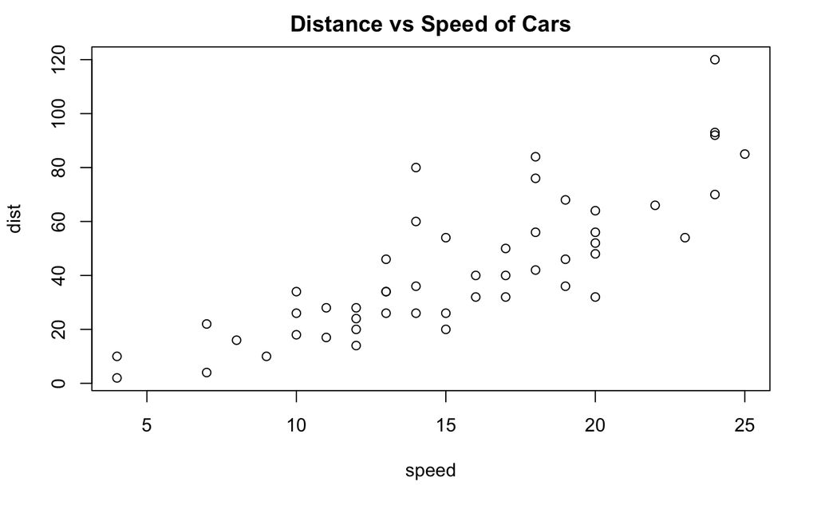

```r
plot(cars, main="Distance vs Speed of Cars")
```

# The Basics

A copy of *Learning R* by Cotton (published by O’Reilly) is available in your Google Drive. I will follow its examples closely, while offering some methods that I found useful (and fairly efficient, of course).

## Declaring Objects

**Assigning variables** is an important part of any languages; for historical reasons, I prefer using “<-” to assign variables, though “=” works just as well.

```r
x <- 1:5
y = 6:10
x + 2 * y - 3 # (algebraically written as -3 + x + 2y)
```

```
[1] 10 13 16 19 22
```

Without executing the following code: tell me the output from the commmands.

```r
x <- 23:19
y = 1:5
3 * x - 2 * y - 3
```

Variable names can contain letters, numbers, dots, and underscores, but they can’t start with a number, or a dot followed by a number (since that looks too much like a number). Reserved words like “if” and “for” are not allowed. In some locales, non-ASCII letters are allowed, but for code portability it is better to stick to “a” to “z” (and “A” to “Z”). The help page ?make.names gives precise details about what is and isn’t allowed.

We are not always interested in assigning **global variables**; for reasons that will be clear if you learn more general scripting languages such as Python, global variables make codes quite “stiff” and hard to alter. However, for the sake of completeness, one would declare it as follows:

```r
a <<- exp(exp(1))
assign("my_local_variable", 9 ^ 3 + 10 ^ 3)
assign("my_global_variable", 1 ^ 3 + 12 ^ 3, globalenv())
```

There are at least two remarks we can make here:

1. assign() function does exactly what it is supposed to. The extra globalenv() argument is required for making <<- declarations.
2. The distinction between local and global variables is more generally referred to as **scoping**. This would be covered in more details if we have the time to, but scopes, along with **namescapes**, are legitimate concerns for maintaining code in the future.

## Special Numbers

These are to watch out for when we get into cleaning datasets.

```r
c(Inf + 1, Inf - 1, Inf - Inf)
```

```
[1] Inf Inf NaN
```

```r
c(1 / Inf, Inf / 1, Inf / Inf)
```

```
[1]   0 Inf NaN
```

```r
c(sqrt(Inf), sin(Inf))
```

```
NaNs produced
```

```
[1] Inf NaN
```

```r
c(log(Inf), log(Inf, base = Inf))
```

```
NaNs produced
```

```
[1] Inf NaN
```

```r
c(NA + 1, NA * 5, NA + Inf)
```

```
[1] NA NA NA
```

One can easily identify these special numbers in datasetes by using the following commands:

```r
x <- c(0, Inf, -Inf, NaN, NA)
is.finite(x)
```

```
[1]  TRUE FALSE FALSE FALSE FALSE
```

```r
is.infinite(x)
```

```
[1] FALSE  TRUE  TRUE FALSE FALSE
```

```r
is.nan(x)
```

```
[1] FALSE FALSE FALSE  TRUE FALSE
```

```r
is.na(x)
```

```
[1] FALSE FALSE FALSE  TRUE  TRUE
```

## Logic Notations

By *vectorised*, there are at least three common usage; in descending order of usage frequency:

1. An operator or a function that acts on each element of a vector without the need for you to explicitly write a loop (this built-in implicit looping over elements is also much faster than explicitly writing your own loop).
2. When a function takes a vector as an input and calculates a summary statistic.
3. Applies vectorisation over arguments. This is when a function calculates a summary statistic from several of its input arguments. The *sum* function does this, but it is very unusual. *median* does not.

Defining a new $x$ and simultaneously applying a logic statement to a list gives:

```r
(x <- 1:10 >= 5)
```

```
 [1] FALSE FALSE FALSE FALSE  TRUE  TRUE  TRUE  TRUE  TRUE  TRUE
```

```r
(y <- 1:10 %% 2 == 0)
```

```
 [1] FALSE  TRUE FALSE  TRUE FALSE  TRUE FALSE  TRUE FALSE  TRUE
```

```r
x & y
```

```
 [1] FALSE FALSE FALSE FALSE FALSE  TRUE FALSE  TRUE FALSE  TRUE
```

```r
x | y
```

```
 [1] FALSE  TRUE FALSE  TRUE  TRUE  TRUE  TRUE  TRUE  TRUE  TRUE
```

Can you parse what these commands mean, using the logic notations from above?

We can conjure up some **truth tables** to see how they work (don’t worry if this code doesn’t make sense yet; just concentrate on understanding why each value occurs in the truth table):

```r
x <- c(TRUE, FALSE, NA) #the three logical values
xy <- expand.grid(x = x, y = x) #get all combinations of x and y
within( #make the next assignments within xy
  xy,
  {
    and <- x & y
    or <- x | y
    not.y <- !y
    not.x <- !x
  }
)
```

| x | y | not.x | not.y | or | and |
| --- | --- | --- | --- | --- | --- |
| TRUE | TRUE | FALSE | FALSE | TRUE | TRUE |
| FALSE | TRUE | TRUE | FALSE | TRUE | FALSE |
| NA | TRUE | NA | FALSE | TRUE | NA |
| TRUE | FALSE | FALSE | TRUE | TRUE | FALSE |
| FALSE | FALSE | TRUE | TRUE | FALSE | FALSE |
| NA | FALSE | NA | TRUE | NA | FALSE |
| TRUE | NA | FALSE | NA | TRUE | NA |
| FALSE | NA | TRUE | NA | NA | FALSE |
| NA | NA | NA | NA | NA | NA |

The most important takewaway: logic in R is truly quite powerful. We will make use of them when we are cleaning datasets.

## Different Types of Numbers

One can differentiate between different types of numbers by knowing what classes they belong to:

```r
class(sqrt(1:10))
```

```
[1] "numeric"
```

```r
class(3 + 1i) #"i" creates imaginary components of complex numbers
```

```
[1] "complex"
```

```r
class(1) #although this is a whole number, it has class numeric
```

```
[1] "numeric"
```

```r
class(1L) #add a suffix of "L" to make the number an integer
```

```
[1] "integer"
```

```r
class(0.5:4.5) #the colon operator returns a value that is numeric...
```

```
[1] "numeric"
```

```r
class(1:5) #unless all its values are whole numbers
```

```
[1] "integer"
```

There are other types of classes, too:

```r
class(c("she", "sells", "seashells", "on", "the", "sea", "shore"))
```

```
[1] "character"
```

```r
(gender <- factor(c("male", "female", "female", "male", "female")))
```

```
[1] male   female female male   female
Levels: female male
```

The *levels* sublayer allows us to search for objects in the class related to the level. These can be thought of labels confined to specifc *factors*; to see this in action,

```r
levels(gender)
```

```
[1] "female" "male"
```

```r
nlevels(gender)
```

```
[1] 2
```

A lot of operations in R (and any language in general) are *class-specific*. It is possible to write a code to the effect of

```r
if(!is(x, "some_class"))
{
#some corrective measure
}
```

And it is possible to verify classes of objects by the use of *is.$^{\star}$* functions.

```r
is.character("red lorry, yellow lorry")
```

```
[1] TRUE
```

```r
is.logical(FALSE)
```

```
[1] TRUE
```

```r
is.list(list(a = 1, b = 2))
```

```
[1] TRUE
```

```r
ls(pattern = "^is", baseenv())
```

```
 [1] "is.array"                "is.atomic"               "is.call"
 [4] "is.character"            "is.complex"              "is.data.frame"
 [7] "is.double"               "is.element"              "is.environment"
[10] "is.expression"           "is.factor"               "is.finite"
[13] "is.function"             "is.infinite"             "is.integer"
[16] "is.language"             "is.list"                 "is.loaded"
[19] "is.logical"              "is.matrix"               "is.na"
[22] "is.na.data.frame"        "is.na.numeric_version"   "is.na.POSIXlt"
[25] "is.na<-"                 "is.na<-.default"         "is.na<-.factor"
[28] "is.na<-.numeric_version" "is.name"                 "is.nan"
[31] "is.null"                 "is.numeric"              "is.numeric_version"
[34] "is.numeric.Date"         "is.numeric.difftime"     "is.numeric.POSIXt"
[37] "is.object"               "is.ordered"              "is.package_version"
[40] "is.pairlist"             "is.primitive"            "is.qr"
[43] "is.R"                    "is.raw"                  "is.recursive"
[46] "is.single"               "is.symbol"               "is.table"
[49] "is.unsorted"             "is.vector"               "isatty"
[52] "isBaseNamespace"         "isdebugged"              "isIncomplete"
[55] "isNamespace"             "isNamespaceLoaded"       "isOpen"
[58] "isRestart"               "isS4"                    "isSeekable"
[61] "isSymmetric"             "isSymmetric.matrix"      "isTRUE"
```

One small oddity is that *is.numeric* returns *TRUE* for integers as well as floating point values. If we want to test for only floating point numbers, then we must use *is.double*. However, this isn’t usually necessary, as R is designed so that floating point and integer values can be used more or less interchangeably. In the following examples, note that adding an L suffix makes the number into an integer:

```r
is.numeric(1)
```

```
[1] TRUE
```

```r
is.numeric(1L)
```

```
[1] TRUE
```

```r
is.integer(1)
```

```
[1] FALSE
```

```r
is.integer(1L)
```

```
[1] TRUE
```

```r
is.double(1)
```

```
[1] TRUE
```

```r
is.double(1L)
```

```
[1] FALSE
```

Sometimes we may wish to change the type of an object. This is called casting, and most *is$^{\star}$* functions have a corresponding *as$^{\star}$* function to achieve it. The specialized *as$^{\star}$* functions should be used over plain *as* when available, since they are usually more efficient, and often contain extra logic specific to that class. For example, when converting a string to a number, *as.numeric* is slightly more efficient than plain *as*, but either can be used:

```r
x <- "123.456"
as(x, "numeric")
```

```
[1] 123.456
```

```r
as.numeric(x)
```

```
[1] 123.456
```

A common data structure we will be dealing with in R is called **data frame**. It is sort of like a spreadsheet, but much more flexible and mutable than one would see in Excel.

```r
y <- c(2, 12, 343, 34997) #See http://oeis.org/A192892
as.data.frame(y)
```

| y |
| --- |
| 2 |
| 12 |
| 343 |
| 34997 |

The last remark to be made in this section is the idea of *for* loops with vectors: you can do nifty things like this.

```r
ulams_spiral <- c(1, 8, 23, 46, 77) #See http://oeis.org/A033951
for(i in ulams_spiral) print(i)
```

```
[1] 1
[1] 8
[1] 23
[1] 46
[1] 77
```

```r
print(ulams_spiral)
```

```
[1]  1  8 23 46 77
```

Can you explain the differences between these two prints? What objects are resulted from these prints?

# Data Structures

As is the case with many codes, it is important to understand data structures and the operations associated with every single one of them.

## More on Vectors, Matrices, and Arrays

One can vectorise a set of elements by the *vector()* call. However, it is quite slow and not extremely useful. The smarter thing to do is, generally, to work with sequences. See the following commands:

```r
seq.int(3, 12)
```

```
 [1]  3  4  5  6  7  8  9 10 11 12
```

```r
seq.int(3, 12, 2)
```

```
[1]  3  5  7  9 11
```

```r
seq.int(0.1, 0.01, -0.01)
```

```
 [1] 0.10 0.09 0.08 0.07 0.06 0.05 0.04 0.03 0.02 0.01
```

```r
n <- 0
1:n
```

```
[1] 1 0
```

Now, the following commands are quite useful for some text-based applications:

```r
pp <- c("Peter", "Piper", "picked", "a", "peck", "of", "pickled", "peppers")
for(i in seq_along(pp)) print(pp[i])
```

```
[1] "Peter"
[1] "Piper"
[1] "picked"
[1] "a"
[1] "peck"
[1] "of"
[1] "pickled"
[1] "peppers"
```

If you already know some coding, you should know that one can easily iterate over numeric list; for that, sometimes length functions are useful.

```r
poincare <- c(1, 0, 0, 0, 2, 0, 2, 0) #See http://oeis.org/A051629
length(poincare)
```

```
[1] 8
```

```r
length(poincare) <- 3
poincare
```

```
[1] 1 0 0
```

A great feature of R’s vectors is that each element can be given a name. Labelling the elements can often make your code much more readable. You can specify names when you create a vector in the form name = value. If the name of an element is a valid variable name, it doesn’t need to be enclosed in quotes. You can name some elements of a vector and leave others blank:

```r
c(apple = 1, banana = 2, "kiwi fruit" = 3, 4)
```

```
     apple     banana kiwi fruit
         1          2          3          4
```

```r
x <- 1:4
names(x) <- c("apple", "bananas", "kiwi fruit", "")
x
```

```
     apple    bananas kiwi fruit
         1          2          3          4
```

And, as expected, one can call the names of these structures by means of the *names()* function:

```r
names(x)
```

```
[1] "apple"      "bananas"    "kiwi fruit" ""
```

We will see this later, but the idea of working with data structures directly (rather than fiddling around with individual pieces of codes) is to gain more flexibility. Think of this remark in the following manner: often times we may want to access only part of a vector, or perhaps an individual element. This is called **indexing** and is accomplished with square brackets, [] (some people also call it subsetting or subscripting or slicing; all these terms refer to the same thing). R has a very flexible system that gives us several choices of index:

- Passing a vector of positive numbers returns the slice of the vector containing the elements at those locations. The first position is 1 (not 0, as in some other languages).
- Passing a vector of negative numbers returns the slice of the vector containing the elements everywhere except at those locations.
- Passing a logical vector returns the slice of the vector containing the elements where the index is TRUE.
- For named vectors, passing a character vector of names returns the slice of the vector containing the elements with those names.

Vector-valued functions act component-wise on a list of elements.

```r
x <- (1:5) ^ 2
x[c(1, 3, 5)]
```

```
[1]  1  9 25
```

```r
x[c(-2, -4)]
```

```
[1]  1  9 25
```

```r
x[c(TRUE, FALSE, TRUE, FALSE, TRUE)]
```

```
[1]  1  9 25
```

And let us give these some names: for people who only want to read numbers written in English letters.

```r
names(x) <- c("one", "four", "nine", "sixteen", "twenty five")
x[c("one", "nine", "twenty five")]
```

```
        one        nine twenty five
          1           9          25
```

Combining the $x$ defined above and the slicing method introduced in the previous lines, and **without** running this code, can you tell me the output?

```r
x[c(1, NA, 5)]
```

```
        one        <NA> twenty five
          1          NA          25
```

```r
x[c(TRUE, FALSE, NA, FALSE, TRUE)]
```

```
        one        <NA> twenty five
          1          NA          25
```

We can always recycle the vectors that we’ve used for different purposes, and to this end, the *rep()* function is extremely useful.

```r
rep(1:5, 3)
```

```
 [1] 1 2 3 4 5 1 2 3 4 5 1 2 3 4 5
```

```r
rep(1:5, each = 3)
```

```
 [1] 1 1 1 2 2 2 3 3 3 4 4 4 5 5 5
```

```r
rep(1:5, times = 1:5)
```

```
 [1] 1 2 2 3 3 3 4 4 4 4 5 5 5 5 5
```

```r
rep(1:5, length.out = 7)
```

```
[1] 1 2 3 4 5 1 2
```

Like the *seq()* function, rep has a simpler and faster variant, *rep.int()*, for the most common case:

```r
rep.int(1:5, 3) # the same as rep(1:5, 3)
```

```
 [1] 1 2 3 4 5 1 2 3 4 5 1 2 3 4 5
```

Recent versions of R (since v3.0.0) also have rep_len, paralleling seq_len, which lets us specify the length of the output vector: try running the command rep_len(1:5, 13) to see the larger point here.

## Arrays and Matrices

We create arrays using the *array()* function:

```r
(three_d_array <- array(
  1:24,
  dim = c(4, 3, 2),
  dimnames = list(
  c("one", "two", "three", "four"),
  c("ein", "zwei", "drei"),
  c("un", "deux")
  )
))
```

```
, , un

      ein zwei drei
one     1    5    9
two     2    6   10
three   3    7   11
four    4    8   12

, , deux

      ein zwei drei
one    13   17   21
two    14   18   22
three  15   19   23
four   16   20   24
```

The syntax for creating matrices is similar, but rather than passing a dim argument, you specify the number of rows or the number of columns:

```r
(a_matrix <- matrix(
  1:12,
  nrow = 4,  #ncol = 3 works the same
  dimnames = list(
  c("one", "two", "three", "four"),
  c("ein", "zwei", "drei")
  )
))
```

```
      ein zwei drei
one     1    5    9
two     2    6   10
three   3    7   11
four    4    8   12
```

And one can easily examine the dimensions of a matrix:

```r
dim(a_matrix)
```

```
[1] 4 3
```

```r
nrow(a_matrix)
```

```
[1] 4
```

```r
ncol(a_matrix)
```

```
[1] 3
```

The length function that we have previously used with vectors also works on matrices and arrays. In this case it returns the product of each of the dimensions! Try this yourself.

It is possible to call the names of the dimensions:

```r
rownames(a_matrix)
```

```
[1] "one"   "two"   "three" "four"
```

```r
colnames(a_matrix)
```

```
[1] "ein"  "zwei" "drei"
```

```r
dimnames(a_matrix)
```

```
[[1]]
[1] "one"   "two"   "three" "four"

[[2]]
[1] "ein"  "zwei" "drei"
```

Indexing the matrix has the following syntax: matrix[row,column]. To see this in practice:

```r
a_matrix[1,]
```

```
 ein zwei drei
   1    5    9
```

```r
a_matrix[,"zwei"]
```

```
  one   two three  four
    5     6     7     8
```

```r
a_matrix[,c("zwei","drei")]
```

```
      zwei drei
one      5    9
two      6   10
three    7   11
four     8   12
```

## Lists

A list is, loosely speaking, a vector where each element can be of a different type. This section concerns how to create, index, and manipulate lists.

The *list()* function is most widely used to create lists from scratch; to see an example:

```r
(a_list <- list(
c(1, 1, 2, 5, 14, 42), #See http://oeis.org/A000108
month.abb,
matrix(c(3, -8, 1, -3), nrow = 2),
asin
))
```

```
[[1]]
[1]  1  1  2  5 14 42

[[2]]
 [1] "Jan" "Feb" "Mar" "Apr" "May" "Jun" "Jul" "Aug" "Sep" "Oct" "Nov" "Dec"

[[3]]
     [,1] [,2]
[1,]    3    1
[2,]   -8   -3

[[4]]
function (x)  .Primitive("asin")
```

As you can see, this list is a series of MANY different objects in R: a numerical array, string array, matrix, and function. One can also associate names to elements in a list (in the previous example, I would call *a_list* a collection of objects):

```r
names(a_list) <- c("catalan", "months", "involutary", "arcsin")
a_list
```

```
$catalan
[1]  1  1  2  5 14 42

$months
 [1] "Jan" "Feb" "Mar" "Apr" "May" "Jun" "Jul" "Aug" "Sep" "Oct" "Nov" "Dec"

$involutary
     [,1] [,2]
[1,]    3    1
[2,]   -8   -3

$arcsin
function (x)  .Primitive("asin")
```

To make things even more complicated and chunky sometimes, we can even embed lists into lists – creating a list of list, if you will:

```r
(main_list <- list(
middle_list = list(
element_in_middle_list = diag(3),
inner_list = list(
element_in_inner_list = pi ^ 1:4,
another_element_in_inner_list = "a"
)
),
element_in_main_list = log10(1:10)
))
```

```
$middle_list
$middle_list$element_in_middle_list
     [,1] [,2] [,3]
[1,]    1    0    0
[2,]    0    1    0
[3,]    0    0    1

$middle_list$inner_list
$middle_list$inner_list$element_in_inner_list
[1] 3.141593

$middle_list$inner_list$another_element_in_inner_list
[1] "a"



$element_in_main_list
 [1] 0.0000000 0.3010300 0.4771213 0.6020600 0.6989700 0.7781513 0.8450980 0.9030900 0.9542425 1.0000000
```

In theory, you can keep nesting lists forever. In practice, current versions of R will throw an error once you start nesting your lists tens of thousands of levels deep (the exact number is machine specific). Luckily, this shouldn’t be a problem for you, since real-world code where nesting is deeper than three or four levels is extremely rare. I will not provide any exercise or situation where deep nesting is necessary at all (and it presents a confusing set of codes anyways – no one needs that).

Due to this ability to contain other lists within themselves, lists are considered to be *recursive variables*. Vectors, matrices, and arrays, by contrast, are atomic (remark: variables can either be recursive or atomic, never both). The functions *is.recursive* and *is.atomic* let us test variables to see what type they are:

```r
is.atomic(list())
```

```
[1] FALSE
```

```r
is.recursive(list())
```

```
[1] TRUE
```

```r
is.atomic(numeric())
```

```
[1] TRUE
```

```r
is.recursive(numeric())
```

```
[1] FALSE
```

Like vectors, lists have lengths; they can be properly described as follows:

```r
length(a_list)
```

```
[1] 4
```

```r
length(main_list)
```

```
[1] 2
```

Lists do not have dimension – so using *dim(list object))* will return NULL. But, it does make sense to speak of the number of rows and columns an object contains:

```r
nrow(a_list)
```

[output not shown]

```r
ncol(a_list)
```

[output not shown]

```r
NROW(a_list)
```

```
[1] 4
```

```r
NCOL(a_list)
```

```
[1] 1
```

and, as is the case with all commands in R, *help()* details the exact syntax of any function:

```r
help("NCOL")
help("NROW")
```

try executing these commands in RStudio (or some other IDE of your choice) and understand what the differences are.

Unlike with vectors, arithmetic doesn’t work on lists. Since each element can be of a different type, it doesn’t make sense to be able to add or multiply two lists together. It is possible to do arithmetic on list elements, however, assuming that they are of an appropriate type. In that case, the usual rules for the element contents apply. For example:

```r
l1 <- list(1:5)
l2 <- list(6:10)
l1[[1]] + l2[[1]]
```

```
[1]  7  9 11 13 15
```

One can also index lists:

```r
l <- list(
  first = 1,
  second = 2,
  third = list(
  alpha = 3.1,
  beta = 3.2
  )
)
```

and the result is predictable:

```r
l[1:2]
```

```
$first
[1] 1

$second
[1] 2
```

```r
l[-3]
```

```
$first
[1] 1

$second
[1] 2
```

```r
l[c("first", "second")]
```

```
$first
[1] 1

$second
[1] 2
```

```r
l[c(TRUE, TRUE, FALSE)]
```

```
$first
[1] 1

$second
[1] 2
```

The result of these indexing operations is **another list**. Sometimes we want to access the contents of the list elements instead. There are two operators to help us do this. Double square brackets ([[]]) can be given a single positive integer denoting the index to return, or a single string naming that element:

```r
l[[1]]
```

```
[1] 1
```

```r
l[["first"]]
```

```
[1] 1
```

Again, *is.list()* function returns TRUE or FALSE – the former if the object is a list, the latter if not.

Sometimes, it is convenient to convert vectors to lists: this can be done using the function function *as.list()*. This creates a list with each element of the vector mapping to a list element containing one value:

```r
busy_beaver <- c(1, 6, 21, 107) #See http://oeis.org/A060843
as.list(busy_beaver)
```

```
[[1]]
[1] 1

[[2]]
[1] 6

[[3]]
[1] 21

[[4]]
[1] 107
```

and if each element in the list is a numerical element, then *as.numeric()* makes sense:

```r
as.numeric(list(1, 6, 21, 107))
```

```
[1]   1   6  21 107
```

This technique won’t work in cases where the list contains nonscalar elements. This is a real issue, because as well as storing different types of data, lists are very useful for storing data of the same type, but with a nonrectangular shape:

```r
(prime_factors <- list(
two = 2,
three = 3,
four = c(2, 2),
five = 5,
six = c(2, 3),
seven = 7,
eight = c(2, 2, 2),
nine = c(3, 3),
ten = c(2, 5)
))
```

```
$two
[1] 2

$three
[1] 3

$four
[1] 2 2

$five
[1] 5

$six
[1] 2 3

$seven
[1] 7

$eight
[1] 2 2 2

$nine
[1] 3 3

$ten
[1] 2 5
```

This sort of list can be converted to a vector using the function unlist (it is sometimes technically possible to do this with mixed-type lists, but rarely useful):

```r
unlist(prime_factors)
```

```
   two  three  four1  four2   five   six1   six2  seven eight1 eight2 eight3  nine1  nine2   ten1
     2      3      2      2      5      2      3      7      2      2      2      3      3      2
  ten2
     5
```

What if I want to combine lists that are related to one another? The *c()* function that we have used for concatenating vectors also works for concatenating lists:

```r
c(list(a = 1, b = 2), list(3))
```

```
$a
[1] 1

$b
[1] 2

[[3]]
[1] 3
```

```r
c(list(a = 1, b = 2), 3)
```

```
$a
[1] 1

$b
[1] 2

[[3]]
[1] 3
```

And, more useful than not, we can actually use *rbind()* and *cbind()* functions to assemble some datasets (at least, I’ve found these helpful – in cases where datasets, after assembly, look rectangular). An example is as follows:

```r
(matrix_list_hybrid <- cbind(
list(a = 1, b = 2),
list(c = 3, list(d = 4))
))
```

```
  [,1] [,2]
a 1    3
b 2    List,1
```

Some might argue that this use of bind functions is “illegal”, in the sense that they destroy datasets the way they appear. It makes analyses slightly more challenging and unnecessarily clunky. I agree, but these functions also provide a way for us to toy around with the existing datasets, to analyse them in ways that we cannot previously – because of inherent limitation in how data is collected. One might argue that these functions form another case of R being a little too flexible and accommodating, instead of telling you that you’ve done something silly by throwing an error.

# NULL

NULL is a special value that represents an empty variable. Its most common use is in lists, but it also crops up with data frames and function arguments. These other uses will be discussed later.

When you create a list, you may wish to specify that an element should exist, but should have no contents. For example, the following list contains UK bank holidays (which are *public holidays*) for 2013 by month. Some months have no bank holidays, so we use NULL to represent this absence:

```r
(uk_bank_holidays_2013 <- list(
  Jan = "New Year's Day",
  Feb = NULL,
  Mar = "Good Friday",
  Apr = "Easter Monday",
  May = c("Early May Bank Holiday", "Spring Bank Holiday"),
  Jun = NULL,
  Jul = NULL,
  Aug = "Summer Bank Holiday",
  Sep = NULL,
  Oct = NULL,
  Nov = NULL,
  Dec = c("Christmas Day", "Boxing Day")
))
```

```
$Jan
[1] "New Year's Day"

$Feb
NULL

$Mar
[1] "Good Friday"

$Apr
[1] "Easter Monday"

$May
[1] "Early May Bank Holiday" "Spring Bank Holiday"

$Jun
NULL

$Jul
NULL

$Aug
[1] "Summer Bank Holiday"

$Sep
NULL

$Oct
NULL

$Nov
NULL

$Dec
[1] "Christmas Day" "Boxing Day"
```

```r
length(NULL)
```

```
[1] 0
```

```r
length(NA)
```

```
[1] 1
```

```r
is.null(NULL)
```

```
[1] TRUE
```

```r
is.null(NA)
```

```
[1] FALSE
```

There are many examples and trivial/unused functions that are potentially useful in some scenario, but we won’t find use for them. The following, though, is wildly important.

## DataFrame

Data frames are used to store spreadsheet-like data. They can either be thought of as matrices where each column can store a different type of data, or nonnested lists where each element is of the same length.

An example:

```r
(a_data_frame <- data.frame(
  x = letters[1:5],
  y = rnorm(5),
  z = runif(5) > 0.5
  )
)
```

| x | y | z |
| --- | --- | --- |
| a | 1.1977645 | TRUE |
| b | 0.4043360 | TRUE |
| c | -1.4789061 | FALSE |
| d | 0.8334093 | TRUE |
| e | -0.4523682 | TRUE |

```r
class(a_data_frame)
```

```
[1] "data.frame"
```

We can also create “random matrices”, which speaks to how flexible this environment is:

```r
y <- rnorm(5)
names(y) <- month.name[1:5]
data.frame(
  x = letters[1:5],
  y = y,
  z = runif(5) > 0.5
)
```

|  | x | y | z |
| --- | --- | --- | --- |
| January | a | 0.589537577 | TRUE |
| February | b | -0.511108473 | FALSE |
| March | c | 0.007739448 | TRUE |
| April | d | 0.300367574 | FALSE |
| May | e | -0.652001793 | FALSE |

this is one of the best places where we can run simulations in: in mathematics, we care about properties of objects. Having these tools at our disposal make it a lot easier for us to see big ideas – before/after we prove the properties.

In addition, names can be overridden by using an extra argument:

```r
data.frame(
x = letters[1:5],
y = y,
z = runif(5) > 0.5,
row.names = NULL
)
```

| x | y | z |
| --- | --- | --- |
| a | 0.589537577 | TRUE |
| b | -0.511108473 | TRUE |
| c | 0.007739448 | FALSE |
| d | 0.300367574 | TRUE |
| e | -0.652001793 | FALSE |

or changed altogether by

```r
data.frame(
x = letters[1:5],
y = y,
z = runif(5) > 0.5,
row.names = c("Jackie", "Tito", "Jermaine", "Marlon", "Michael")
)
```

|  | x | y | z |
| --- | --- | --- | --- |
| Jackie | a | 0.589537577 | FALSE |
| Tito | b | -0.511108473 | TRUE |
| Jermaine | c | 0.007739448 | TRUE |
| Marlon | d | 0.300367574 | FALSE |
| Michael | e | -0.652001793 | FALSE |

Dimensions, rows, columns lengths functions all work the same, but with two caveats:

1. *length* returns the same value as *ncol*, not the total number of elements in the data frame.
2. Likewise, names returns the same value as colnames.

It is possible to create a data frame by passing different lengths of vectors, as long as the lengths allow the shorter ones to be recycled an exact number of times. More technically, the lowest common multiple of all the lengths must be equal to the longest vector:

```r
data.frame( #lengths 1, 2, and 4 are OK
  x = 1, #recycled 4 times
  y = 2:3, #recycled twice
  z = 4:7 #the longest input; no recycling
)
```

| x | y | z |
| --- | --- | --- |
| 1 | 2 | 4 |
| 1 | 3 | 5 |
| 1 | 2 | 6 |
| 1 | 3 | 7 |

The following example will fail:

```r
data.frame( #lengths 1, 2, and 3 cause an error
x = 1, #lowest common multiple is 6, which is more than 3
y = 2:3,
z = 4:6
)
```

```r
example <- data.frame(
"A" = letters[1:5],
"B" = rnorm(5),
"C" = runif(5) > 0.5,
check.names = FALSE
)
example
```

| A | B | C |
| --- | --- | --- |
| a | 0.3393940 | FALSE |
| b | 0.5406895 | FALSE |
| c | -0.5328220 | FALSE |
| d | -0.6355775 | FALSE |
| e | 0.7387464 | FALSE |

```r
example[2:4, -2] #all except 2, which is B
```

|  | A | C |
| --- | --- | --- |
| 2 | b | FALSE |
| 3 | c | FALSE |
| 4 | d | FALSE |

```r
example[c(FALSE, TRUE, TRUE, FALSE, FALSE), c("A", "B")]
```

|  | A | B |
| --- | --- | --- |
| 2 | b | 0.5406895 |
| 3 | c | -0.5328220 |

One can always check the classes of the subsetted portions of the dataframe.

```r
class(example[2:3, -3])
```

```
[1] "data.frame"
```

```r
class(example[2:3, 1])
```

```
[1] "factor"
```

```r
# These are three ways to say the same thing.
example$A[2:3]
```

```
[1] b c
Levels: a b c d e
```

```r
example[[1]][2:3]
```

```
[1] b c
Levels: a b c d e
```

```r
example[["A"]][2:3]
```

```
[1] b c
Levels: a b c d e
```

```r
example[example$B > 0 | a_data_frame$C, "A"]
```

[output not shown]

## Basic Data Frame Manipulation

```r
class(example)
```

```
[1] "data.frame"
```

Data frames can also be joined together using cbind and rbind, assuming that they have the appropriate sizes. rbind is smart enough to reorder the columns to match. cbind doesn’t check column names for duplicates, though, so be careful with it:

[output not shown]

```r
merge(example, another_data_frame, by = "A")
```

| A | B.x | C.x | C.y | B.y |
| --- | --- | --- | --- | --- |
| c | -0.5328220 | FALSE | 2.2968084 | 2 |
| d | -0.6355775 | FALSE | 0.4189135 | 5 |
| e | 0.7387464 | FALSE | 6.4918047 | 1 |

```r
merge(example, another_data_frame, by = "A", all=TRUE)
```

| A | B.x | C.x | C.y | B.y |
| --- | --- | --- | --- | --- |
| a | 0.3393940 | FALSE | NA | NA |
| b | 0.5406895 | FALSE | NA | NA |
| c | -0.5328220 | FALSE | 2.2968084 | 2 |
| d | -0.6355775 | FALSE | 0.4189135 | 5 |
| e | 0.7387464 | FALSE | 6.4918047 | 1 |
| f | NA | NA | 3.0060601 | 3 |
| g | NA | NA | 1.2340468 | 4 |

Where a data frame has all numeric values, the functions *colSums* and *colMeans* can be used to calculate the sums and means of each column, respectively. Similarly, *rowSums* and *rowMeans* calculate the sums and means of each row:

```r
colSums(example[, 2:3])
```

```
        B         C
0.4504304 0.0000000
```

```r
colMeans(example[, 2:3])
```

```
         B          C
0.09008608 0.00000000
```